# Conjoint Analysis High Education

# Librerias

```r
library(tidyverse)
library(nnet)
library(conjoint)
library(knitr)
```

# Leyendo y transformando datos

```r
readxl::read_excel("C:/Users/samora/OneDrive - Politécnico Grancolombiano/Poli/Criterios de decisión de un estudiante al momento de escoger una IES - Depurada - copia.xlsx") -> data
data %>% head() %>% kable()
```

| AreaConocimiento | TipoInstitucion_ | TieneFuturoProfesional_ | ProgramaTienePrestigio_ | GeneraBuenSalario_ | DesarrolloProfesional_ | UniversidadDeseada_ | RazonesEstudio_ | RazonesEstudio2_ | RazonesEstudio3_ | RazonesEstudio4_ | RazonesEstudio5_ | RazonesEstudio6_ | otivacionFamiliarPorPrestigio_ | ObligacionFamiliar_ | FamiliaNoInfluyeDecicion_ | reputacionInstitucion_ | reputacionInstitucion2_ | reputacionInstitucion3_ | reputacionInstitucion4_ | TipoInstitucionEsperada_ | ImportanteCalidadProgramas_ | DuracionPrograma_ | MenorTiempo_ | MismoTiempo_ | MayorTiempo_ | CostosPrograma_ | CostoVidaUniversitario_ | ReferenciasEleccion_ | ReferenciasEleccion2_ | … |
| --- | --- | --- | --- | --- | --- | --- | --- | --- | --- | --- | --- | --- | --- | --- | --- | --- | --- | --- | --- | --- | --- | --- | --- | --- | --- | --- | --- | --- | --- | --- |
| INGENIERIA, ARQUITECTURA, URBANISMO Y AFINES | Escuela Publica | De acuerdo | Indiferente | De acuerdo | Totalmente de acuerdo | Universidad de San Buenaventura | Posibilidades de trabajo en el futuro | Por recomendaciones | NA | NA | NA | NA | Indiferente | De acuerdo | Indiferente | La Institucion es reconocida a nivel regional | NA | NA | NA | Privada | Muy Importante | Entre 4 y 5 años | 1 | 1 | 1 | Costoso | Costoso | De un profesor_instructor | NA | … |
| CIENCIAS DE LA SALUD | Ya estoy en una Institucion de Educacion Superior (tecnica/tecnologica/universitaria) | De acuerdo | Indiferente | De acuerdo | De acuerdo | Universidad Distrital | Excelencia Academica | NA | NA | NA | NA | NA | De acuerdo | De acuerdo | De acuerdo | La Institucion es reconocida a nivel local | NA | NA | NA | Privada | Muy Importante | Entre 3 y 4 años | 4 | 4 | 4 | Costoso | Costoso | De un amigo | NA | … |
| CIENCIAS DE LA SALUD | Ya estoy en una Institucion de Educacion Superior (tecnica/tecnologica/universitaria) | De acuerdo | Totalmente de acuerdo | De acuerdo | De acuerdo | No sabe_No responde | Excelencia Academica | Posibilidades de trabajo en el futuro | Prestigio de la Institucion | NA | NA | NA | De acuerdo | En total desacuerdo | De acuerdo | La Institucion es reconocida a nivel nacional | NA | NA | NA | Privada | Muy Importante | Entre 4 y 5 años | 4 | 4 | 4 | Asequible | Asequible | De un familiar | NA | … |
| CIENCIAS DE LA SALUD | Ya estoy en una Institucion de Educacion Superior (tecnica/tecnologica/universitaria) | De acuerdo | Indiferente | Indiferente | De acuerdo | Universidad Javeriana | Por recomendaciones | NA | NA | NA | NA | NA | Totalmente de acuerdo | De acuerdo | De acuerdo | La Institucion es reconocida a nivel nacional | NA | NA | NA | Privada | Muy Importante | Entre 4 y 5 años | 5 | 5 | 1 | Muy costoso | Muy costoso | Redes Sociales | NA | … |
| CIENCIAS DE LA SALUD | Ya estoy en una Institucion de Educacion Superior (tecnica/tecnologica/universitaria) | De acuerdo | De acuerdo | De acuerdo | De acuerdo | UNICOC | Prestigio de la Institucion | NA | NA | NA | NA | NA | De acuerdo | Indiferente | En total desacuerdo | La Institucion es reconocida a nivel nacional | NA | NA | NA | Privada | Muy Importante | Entre 3 y 4 años | 5 | 5 | 1 | Muy costoso | Muy costoso | De un familiar | NA | … |
| CIENCIAS DE LA SALUD | Ya estoy en una Institucion de Educacion Superior (tecnica/tecnologica/universitaria) | De acuerdo | De acuerdo | De acuerdo | Totalmente de acuerdo | Universidad de la Sabana | Posibilidades de trabajo en el futuro | NA | NA | NA | NA | NA | De acuerdo | En total desacuerdo | De acuerdo | La Institucion es reconocida a nivel nacional | NA | NA | NA | Privada | Muy Importante | Entre 4 y 5 años | 5 | 4 | 1 | Costoso | Costoso | De un familiar | NA | … |

```r
data %>% glimpse()
```

```
## Observations: 472
## Variables: 52
## $ AreaConocimiento                      <chr> "INGENIERIA, ARQUITECTUR...
## $ TipoInstitucion_                      <chr> "Escuela Publica", "Ya e...
## $ TieneFuturoProfesional_               <chr> "De acuerdo", "De acuerd...
## $ ProgramaTienePrestigio_               <chr> "Indiferente", "Indifere...
## $ GeneraBuenSalario_                    <chr> "De acuerdo", "De acuerd...
## $ DesarrolloProfesional_                <chr> "Totalmente de acuerdo",...
## $ UniversidadDeseada_                   <chr> "Universidad de San Buen...
## $ RazonesEstudio_                       <chr> "Posibilidades de trabaj...
## $ RazonesEstudio2_                      <chr> "Por recomendaciones", N...
## $ RazonesEstudio3_                      <chr> NA, NA, "Prestigio de la...
## $ RazonesEstudio4_                      <chr> NA, NA, NA, NA, NA, NA, ...
## $ RazonesEstudio5_                      <chr> NA, NA, NA, NA, NA, NA, ...
## $ RazonesEstudio6_                      <chr> NA, NA, NA, NA, NA, NA, ...
```

[output cut: 39 more lines]

## VOCACIONALES

- “Tipo de Institución en la que estudia”
- “b. Le gusta porque tiene futuro profesional”
- “e. Le parece interesante porque el programa tiene prestigio”
- “f. Le parece interesante porque el programa le puede generar buen salario”
- “g. Le parece interesante porque el programa le genera desarrollo profesional y personal”
- “¿En qué universidad le gustaría / le hubiera gustado estudiar?”
- “¿Por qué piensa que puede estudiar allí?”
- “2. Sus familiares lo motivan a estudiar en la universidad por prestigio”
- “3. Sus familiares lo obligan a estudiar porque es necesario estudiar un programa técnico/tecnológico/universitario”
- “5. Sus familiares no influyen en su decisión de estudiar en una universidad”

## ELECCION

- “Prestigio / Reputación de la Institución”
- “La institución a la que piensa acceder/a la que accedió, es:”
- “¿Es importante la calidad de los programas en los cuales está interesado?”
- “El programa que escogerá / ha escogido debe tener una duración de:”
- “El programa ofrece la posibilidad de graduarse en menor tiempo comparado con otras instituciones”
- “El programa ofrece la posibilidad de graduarse en mismo tiempo que en otras instituciones”
- “El programa ofrece la posibilidad de graduarse en mayor tiempo que en el resto de Instituciones”

## DE SELECCION

- “Usted considera que el costo del programa que cursa/desea cursar es:”
- “Usted considera que el costo de vida de la ciudad donde va a cursar / cursa su programa universitario es:”
- “¿Dónde tuvo referencias del programa a escoger / escogido? (también con respecto a institución)?”
- “En relación con el dinero para pagar su (futura) carrera:”
- “Es posible que tenga acceso a programas de excelencia académica para estudiar en cualquier universidad”
- “Tengo dificultad en estudiar en la universidad que quiero porque no tengo los medios para hacerlo”
- “Debo acceder a otro programa porque la Universidad tiene procesos de admisión que limitan el acceso a lo que me gusta”

## DE ORIGEN

- “¿Cuál es su estrato socioeconómico actual?”
- “Nivel de Ingresos para poder pagar mis estudios en una Institución de Educación Superior:”
- “Nivel de estudios del grupo familiar Madre de Familia”
- “¿En qué departamento estudia / estudió su educación secundaria?”
- “¿En qué ciudad estudia / estudió su educación secundaria?”
- “¿En qué país estudia / quiere estudiar su educación superior?”
- “¿En qué departamento/estado estudia / quiere estudiar su educación superior?”
- “¿En qué ciudad estudia / quiere estudiar su educación superior?”

# Transformando datos

```r
#' cambindo a factores
data %>% mutate_if(is.character, as.factor) -> data
#' quitando factores con unica respuesta
bagged <- list()
for (n in names(data))
  if (is.factor(data[[n]]) & length(levels(data[[n]])) < 2) {
    bagged[n] <- n
    print(n)
    print(levels(data[[n]]))
  }
```

```
## [1] "RazonesEstudio6_"
## [1] "Por deseo de mis padres"
## [1] "reputacionInstitucion4_"
## [1] "La Institucion es reconocida por su facilidad para entrar"
## [1] "ReferenciasEleccion7_"
## [1] "De personas que han estudiado alli"
## [1] "NivelIngresos3_"
## [1] "Debo trabajar para poderme pagar mis estudios superiores"
```

```r
bagged %>% unlist() -> bagged
if (!is.null(bagged)) data %>% dplyr::select(-bagged) -> data
#' Transformando y resumiendo valores
#data %>% group_by(AreaConocimiento) %>% count(as.numeric(TipoInstitucion), as.numeric(TieneFuturoProfesional)) -> dataModel
data %>% group_by(AreaConocimiento) %>% tally()
```

```
## # A tibble: 10 x 2
##    AreaConocimiento                                  n
##    <fct>                                         <int>
##  1 AGRONOMIA, VETERINARIA Y AFINES                   5
##  2 BELLAS ARTES                                     21
##  3 CIENCIAS DE LA EDUCACION                         15
##  4 CIENCIAS DE LA SALUD                             60
##  5 CIENCIAS SOCIALES Y HUMANAS                      46
##  6 ECONOMIA, ADMINISTRACION, CONTADURIA Y AFINES    31
##  7 INGENIERIA, ARQUITECTURA, URBANISMO Y AFINES     68
##  8 MATEMATICAS Y CIENCIAS NATURALES                  7
##  9 N/A                                             212
## 10 OTROS                                             7
```

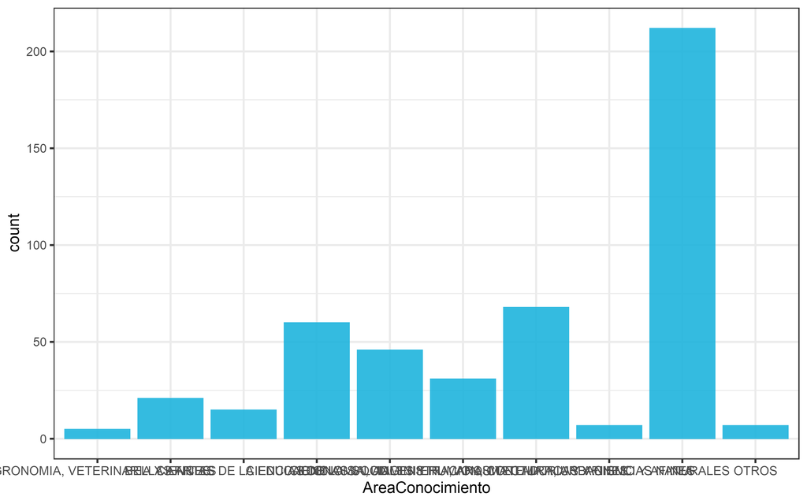

```r
ggplot(data, aes(x = AreaConocimiento)) + geom_histogram(fill = rgb(30/255,180/255,220/255,0.9),stat = "count") + theme_bw()
```

# Modelo Probabilistico

## Build Model

```r
data$AreaConocimiento = relevel(data$AreaConocimiento, ref = "INGENIERIA, ARQUITECTURA, URBANISMO Y AFINES")
test <- multinom(AreaConocimiento ~ TipoInstitucion_ +
      # VOCACIONALES
                   TieneFuturoProfesional_ +
                   ProgramaTienePrestigio_ +
                   GeneraBuenSalario_ +
                   DesarrolloProfesional_ +
                   RazonesEstudio_ +
                   otivacionFamiliarPorPrestigio_+
                   ObligacionFamiliar_+
                   FamiliaNoInfluyeDecicion_+
      # ELECCION
                   reputacionInstitucion_+
                   TipoInstitucionEsperada_+
                   ImportanteCalidadProgramas_+
                   DuracionPrograma_+
                   MenorTiempo_+
      # DE SELECCION
                   CostosPrograma_+
                   CostoVidaUniversitario_+
                   ReferenciasEleccion_+
                   RelacionPagoCarrera_+
                   PosibilidadAccesoExcelenciaAcademica_+
                   DificultadPorFaltaMedios_+
                   ProcesosAdmisionLimitanAcceso_+
      # DE ORIGEN
                   Estrato_+
                   NivelIngresos_+
                   NivelEstudiosMadre_
                 , data = data)
#summary(test)
z <- summary(test)$coefficients/summary(test)$standard.errors
# 2-tailed z test
p <- (1 - pnorm(abs(z), 0, 1)) * 2
```

### Probabilidades (Odds-Ratio)

```r
exp(coef(test)) %>% kable()
```

|  | (Intercept) | TipoInstitucion_Colegio Privado | TipoInstitucion_Escuela Publica | TipoInstitucion_Estudio desde mi casa | TipoInstitucion_Ya estoy en una Institucion de Educacion Superior (tecnica/tecnologica/universitaria) | TieneFuturoProfesional_En desacuerdo | TieneFuturoProfesional_En total desacuerdo | TieneFuturoProfesional_Indiferente | TieneFuturoProfesional_Totalmente de acuerdo | ProgramaTienePrestigio_En desacuerdo | ProgramaTienePrestigio_En total desacuerdo | ProgramaTienePrestigio_Indiferente | ProgramaTienePrestigio_Totalmente de acuerdo | GeneraBuenSalario_En desacuerdo | GeneraBuenSalario_En total desacuerdo | GeneraBuenSalario_Indiferente | GeneraBuenSalario_Totalmente de acuerdo | DesarrolloProfesional_En desacuerdo | DesarrolloProfesional_En total desacuerdo | DesarrolloProfesional_Indiferente | DesarrolloProfesional_Totalmente de acuerdo | RazonesEstudio_Excelencia Academica | RazonesEstudio_Por deseo de mis padres | RazonesEstudio_Por recomendaciones | RazonesEstudio_Posibilidades de trabajo en el futuro | RazonesEstudio_Prestigio de la Institucion | otivacionFamiliarPorPrestigio_En desacuerdo | otivacionFamiliarPorPrestigio_En total desacuerdo | otivacionFamiliarPorPrestigio_Indiferente | … |
| --- | --- | --- | --- | --- | --- | --- | --- | --- | --- | --- | --- | --- | --- | --- | --- | --- | --- | --- | --- | --- | --- | --- | --- | --- | --- | --- | --- | --- | --- | --- |
| AGRONOMIA, VETERINARIA Y AFINES | 0.0000273 | 0.0000000 | 32.1519151 | 12.2593666 | 1189127.3136352 | 2.2514545 | 67.7040609 | 1.1738688 | 27.0726754 | 54.0880586 | 0.0774671 | 4.2770567 | 1.4082453 | 439.9572129 | 372.0689 | 0.0056738 | 0.0873621 | 0.4417292 | 0.2039583 | 0.0003417 | 0.0001466 | 7.7363326 | 0.1659306 | 0.0630977 | 0.5546441 | 677826.7426310 | 4.6636974 | 1189.5942602 | 0.0013557 | … |
| BELLAS ARTES | 0.0000000 | 0.0000008 | 0.0000000 | 0.0000000 | 0.0000000 | 3769550939498876348802860822.0000000 | 0.0069501 | 3.0690974 | 0.0000000 | 385.8661455 | 0.0000032 | 0.0000000 | 0.0000000 | 31972.7843854 | 99956926655.0568 | 496801.6505070 | 1568330.9778013 | 0.0000000 | 520243319612299542528.0000000 | 0.0000000 | 1591.4595302 | 0.0012275 | 0.0000001 | 342.9580881 | 137.6976504 | 0.0227254 | 0.0000000 | 6048478414.4966602 | 5407.1018222 | … |
| CIENCIAS DE LA EDUCACION | 0.0000000 | 0.0000000 | 1915.8397298 | 0.0000000 | 1500077738.4623392 | 0.0002156 | 1.8626893 | 238876.5921901 | 0.1461066 | 0.0048222 | 0.0000000 | 0.0416689 | 0.5853995 | 120689498.5792682 | 245693187385676.1562 | 2308299253566662.5000000 | 0.0000000 | 3.0169392 | 4.2946762 | 0.0000000 | 57.7562329 | 933.6050167 | 538963898772595584.0000000 | 3469.4538858 | 0.0000000 | 8866696214.4744987 | 0.0008793 | 11.0594901 | 74.8237869 | … |
| CIENCIAS DE LA SALUD | 0.0000000 | 0.0000007 | 0.0000068 | 0.1361818 | 0.0060117 | 1306842034388404224.0000000 | 7992974862355784109806804886.0000000 | 0.7804905 | 78.5333630 | 44.4442587 | 0.0000000 | 16.3312802 | 0.2844149 | 0.5240293 | 10519506648336704.0000 | 0.0370544 | 0.3905052 | 0.0000000 | 0.0000193 | 0.0000000 | 7.5147191 | 2.4858271 | 0.0000000 | 11221.8028685 | 0.0193830 | 161.9811027 | 0.5752519 | 122.0837682 | 0.3932538 | … |
| CIENCIAS SOCIALES Y HUMANAS | 0.0008363 | 0.1953263 | 0.2558903 | 32.7836750 | 0.2165872 | 3691346795796575232.0000000 | 0.0000000 | 0.0517897 | 20.8180611 | 117.5339493 | 46296126432076480.0000000 | 20.9363793 | 2.6687331 | 0.0005286 | 0.0000 | 0.0871380 | 1.5522359 | 118.5324072 | 0.6480337 | 0.0000000 | 0.8699270 | 0.0885282 | 9.7097678 | 0.0027814 | 0.1683428 | 2.7434163 | 273.3841464 | 13811.8977342 | 17.2432856 | … |
| ECONOMIA, ADMINISTRACION, CONTADURIA Y AFINES | 0.0000000 | 0.0000005 | 195.1785037 | 0.0000000 | 2694.4787930 | 0.0000000 | 0.0000000 | 0.0000000 | 0.0025217 | 5.3623874 | 27184160342501295246462802826644028280004.0000000 | 0.0000241 | 3247344258.3083501 | 78257275562.2919769 | 0.0000 | 0.1876482 | 214.6979856 | 0.0000012 | 9.7160900 | 0.0000016 | 0.0049893 | 0.0000001 | 0.0000000 | 0.0000000 | 0.0000000 | 0.0000000 | 110.9333672 | 435788486451723.4375000 | 14243600.5122458 | … |
| MATEMATICAS Y CIENCIAS NATURALES | 0.0000000 | 0.0147152 | 3180235.4482647 | 0.0000063 | 0.0000361 | 0.3227308 | 2.8851494 | 0.2130435 | 0.0043255 | 10348705.2417179 | 123994847021.8647919 | 79.3330968 | 49.8885579 | 512766138514.1904297 | 228.5256 | 899984275.6748751 | 270.4309861 | 6.0611977 | 6.1487203 | 989.1047094 | 128.5234879 | 0.0095974 | 0.0082876 | 0.7425210 | 0.0009227 | 0.0000001 | 18134.7740831 | 0.0086326 | 11792.0460288 | … |
| N/A | 0.0000000 | 107732295420906997936882428.0000000 | 126823484839016808592864260.0000000 | 0.0000000 | 0.0000000 | 2880411204796906.5000000 | 290992613404148636848242.0000000 | 1.8833917 | 0.5534007 | 12.7954080 | 57526220241703728.0000000 | 2.8708446 | 1.6671308 | 41.1054142 | 41319761638.3730 | 0.8983665 | 2.0993290 | 22.6470377 | 0.0000000 | 0.9926112 | 0.5273280 | 0.6277425 | 0.7440179 | 0.3798753 | 1.0670523 | 0.2397341 | 7.0794692 | 3.0298742 | 4.2549963 | … |
| OTROS | 0.0010260 | 0.0026712 | 0.0000078 | 0.0000000 | 0.0000001 | 6.7306634 | 367.4201071 | 0.0000000 | 0.3332653 | 188428214.2671253 | 89.7774905 | 1859021.3561198 | 11.9031174 | 33679.7475804 | 3511.7050 | 1941319.9574869 | 553.0794161 | 0.0000006 | 8.3637682 | 0.4090653 | 695.1348386 | 0.0000428 | 11794512225468904.0000000 | 0.0000023 | 0.5712199 | 0.0000000 | 0.0000786 | 0.0000000 | 6.3895411 | … |

### Intervalos de confianza de Probabilidades (Odd-Ratio)

```r
exp(confint(test)) %>% kable()
```

|  | 2.5 %.AGRONOMIA, VETERINARIA Y AFINES | 97.5 %.AGRONOMIA, VETERINARIA Y AFINES | 2.5 %.BELLAS ARTES | 97.5 %.BELLAS ARTES | 2.5 %.CIENCIAS DE LA EDUCACION | 97.5 %.CIENCIAS DE LA EDUCACION | 2.5 %.CIENCIAS DE LA SALUD | 97.5 %.CIENCIAS DE LA SALUD | 2.5 %.CIENCIAS SOCIALES Y HUMANAS | 97.5 %.CIENCIAS SOCIALES Y HUMANAS | 2.5 %.ECONOMIA, ADMINISTRACION, CONTADURIA Y AFINES | 97.5 %.ECONOMIA, ADMINISTRACION, CONTADURIA Y AFINES | 2.5 %.MATEMATICAS Y CIENCIAS NATURALES | 97.5 %.MATEMATICAS Y CIENCIAS NATURALES | 2.5 %.N/A | 97.5 %.N/A | 2.5 %.OTROS | 97.5 %.OTROS |
| --- | --- | --- | --- | --- | --- | --- | --- | --- | --- | --- | --- | --- | --- | --- | --- | --- | --- | --- |
| (Intercept) | 0.0000000 | 91355965503524144266002608286022808024200442264.0000000 | 0.0000000 | 476676767773676063924642668048600264804480206828.0000000 | 0.0000000 | 1750176402407432385124426642260.0000000 | 0.0000000 | 0.0000000 | 0.0000000 | 4512.3111109 | 0.0000000 | 1015331298978386078066226488862260604406640624224204.0000000 | 0.0000000 | 17091522886299358.0000000 | 0.0000000 | 0.0000000 | 0.0000000 | 24096535166993272144062.0000000 |
| TipoInstitucion_Colegio Privado | 0.0000000 | 17793107167089174883248880262846006206026684.0000000 | 0.0000000 | 20309582931343474848004242242242820084280828888400608840204286.0000000 | 0.0000000 | 263283924962658236042668222400062646824684006060280042.0000000 | 0.0000000 | 0.0011997 | 0.0000000 | 3684470.6128439 | 0.0000000 | 537988220603368159166680684024680400460024488400.0000000 | 0.0000000 | 598759906087492883402882864406266800406.0000000 | 2332422910932231.0000000 | 4976047620805897533640020224262620084.0000000 | 0.0000000 | 51374271946162398512004884886804048664862046.0000000 |
| TipoInstitucion_Escuela Publica | 0.0000000 | 484891204469843106164484228640604600800288686628244282684688602044240884484.0000000 | 0.0000000 | 650666283184185729802042240682.0000000 | 0.0000000 | 141517978506504377602002282468624604204206408422682862.0000000 | 0.0000001 | 0.0008787 | 0.0000000 | 2786592.0027856 | 0.0000000 | 56304223353036112928022686080862446246080806648866206064.0000000 | 0.0000000 | 22333979604311522176604826664484642468868424226840062880606480080226.0000000 | 2823031257113887.5000000 | 5697491399070063570442800428420486462.0000000 | 0.0000000 | 2194564406612573364266064246402402802204464446.0000000 |
| TipoInstitucion_Estudio desde mi casa | 0.0000000 | 25900647135608314132480604862888806242204860844468486206660820406064226240.0000000 | 0.0000000 | 2243491433.5058379 | 0.0000000 | 1779471416431328048100642264682484884622842228626808846.0000000 | 0.0004846 | 38.2658169 | 0.0000024 | 447052571.7265308 | 0.0000000 | 2267971070877721507200660648600284680486884440646046864604684.0000000 | 0.0000043 | 0.0000091 | 0.0000000 | 36376627866207602606880.0000000 | 0.0000000 | 0.0000000 |
| TipoInstitucion_Ya estoy en una Institucion de Educacion Superior (tecnica/tecnologica/universitaria) | 0.0000000 | 608251106553305355480846244268646648022026060228440882220082800604488280402426208628248664664640082484888.0000000 | 0.0000000 | 452227875904073703040662260.0000000 | 0.0000000 | 4184776666710164974064640846208026088222022886628448026448440446626020624.0000000 | 0.0000846 | 0.4273792 | 0.0000000 | 2191891.9670910 | 0.0000000 | 235705167986322967526420404666600284888882622886002640862.0000000 | 0.0000353 | 0.0000369 | 0.0000000 | 0.0000000 | 0.0000000 | 1472548309428983892264844640602866640866246262860806426608.0000000 |
| TieneFuturoProfesional_En desacuerdo | NaN | NaN | 0.0000000 | 2611994633262785652646284204842068080066448848448442426064420224864004264488222086242242248662040024082000844468608864406046464208226.0000000 | NaN | NaN | 0.0000000 | 83241014869430263672288464406828284622428000488462882280640666244486206804624206888648042062486662480.0000000 | 0.0000000 | 5524299280235360494080688446028404626202246682626624224468.0000000 | 0.0000000 | 123110638857060537456446864828668684024.0000000 | 0.3227308 | 0.3227308 | 0.0000000 | 4176271023338792319688280260488608682426848008606662060.0000000 | 6.7306370 | 6.7306898 |
| TieneFuturoProfesional_En total desacuerdo | 67.7040549 | 67.7040670 | 0.0000000 | 1370284532826779156580.0000000 | NaN | NaN | 33499288864122544128.0000000 | 1907134429312456033604622602806862686.0000000 | NaN | NaN | 0.0000000 | 32186254.6307263 | 2.8846956 | 2.8856034 | 1682844537696734.0000000 | 50317601631622568692460882044804.0000000 | 367.4201071 | 367.4201071 |
| TieneFuturoProfesional_Indiferente | 0.0000000 | 86460815434256341112668604480440246020202266448228664648620082200026068488820868.0000000 | 0.0000000 | 557882837615602038848462626804424686666688806824448622662.0000000 | 0.0000000 | 400287452601121541440284080606000262400224622820486084400228620224828228482806.0000000 | 0.0060886 | 100.0508922 | 0.0004357 | 6.1564495 | 0.0000000 | 358946.7657479 | 0.0000000 | 15056181.4031430 | 0.1867098 | 18.9982716 | 0.0000000 | 163129726986749494058466240488840666202426.0000000 |
| TieneFuturoProfesional_Totalmente de acuerdo | 0.0000000 | 72831892501722994572846006822848424460006428808268666642820220464402682044046648648644204466442844.0000000 | 0.0000000 | 4588725508871680032000848482.0000000 | 0.0000000 | 5106597100496731214406628264628064042228662820406046406284666.0000000 | 1.9934939 | 3093.8088601 | 2.0240511 | 214.1209134 | 0.0000000 | 19458240992.6231804 | 0.0000000 | 3140863113061946712420680226880208200468.0000000 | 0.1466587 | 2.0881970 | 0.0000000 | 3267547425223239106028642206220626642444024466480844628848620.0000000 |
| ProgramaTienePrestigio_En desacuerdo | 0.0000000 | 4173425525002790030006226682880040862420426422222808602268266424262022202846828808022800844064086282448024464.0000000 | 0.0000000 | 65259680566142566764824624428248284266266460244606462620068.0000000 | 0.0000000 | 6238587331022489159848820402860886448428882406060402024646846282482880466846006222848048604466446608844804640.0000000 | 0.4822573 | 4095.9298881 | 1.0576431 | 13061.3339854 | 0.0000000 | 3171555124366654976.0000000 | 0.0000000 | 443127797470373467520044002624084022222686646226226444880464460044288604806000000248806240228828288244406084426840646486660.0000000 | 0.4745861 | 344.9794884 | 0.0000000 | 111081050266967184200486866004626648020024260008.0000000 |
| ProgramaTienePrestigio_En total desacuerdo | 0.0774645 | 0.0774698 | 0.0000000 | 534859861191412992.0000000 | 0.0000000 | 0.0000000 | 0.0000000 | 200792630940490203942406482.0000000 | 0.0000000 | 82423178219830766912060824488088626044448220424086248666806488882644440462004204466206888240440800664224002.0000000 | 0.0000000 | 67184531407338909178242424866006402044020428864842086642828680406406686644840006400002280442684084282204486600862408620828428680686442282028.0000000 | 1358431.1055031 | 11317999143049034.0000000 | 0.0000000 | 98741014530586831606828202422026044842882028280020684842442600484822682886402204446664882026266284244862028.0000000 | 89.7774905 | 89.7774905 |
| ProgramaTienePrestigio_Indiferente | 0.0000000 | 128884162799184505584264866200800222240446464604640080606484260048226682042428066624064844006642202820.0000000 | 0.0000000 | 1950636325716973354082064424688888248408062048880022222400.0000000 | 0.0000000 | 24602588590270031086820644240826886204804062680006844226040886862266684420488428844.0000000 | 0.5331867 | 500.2201024 | 1.9717636 | 222.3045313 | 0.0000000 | 1323557.9356350 | 0.0000000 | 79307069584147318184442088628646286880662628080884864462068482446844000264608466.0000000 | 0.6144272 | 13.4137105 | 0.0000000 | 71536994471845427904062620664886882666624224680880802482620484062646422.0000000 |
| ProgramaTienePrestigio_Totalmente de acuerdo | 0.0000000 | 855956193961881186088040006260244222262222426848264486608248860804060800282022286804608288684282684484066848880600864626006602442.0000000 | 0.0000000 | 167957890522028834826.0000000 | 0.0000000 | 56383798182239742938028206420864620284642606048888088046240040648400828.0000000 | 0.0079734 | 10.1451993 | 0.2684373 | 26.5318411 | 0.0002810 | 37526802120118131228862.0000000 | 0.0000000 | 24933679211771148884888640802264684240684668248820220268006266600620.0000000 | 0.4083644 | 6.8059919 | 0.0000000 | 10538758599675244331444840842264424064664444200426684886488048828888446440420408.0000000 |
| GeneraBuenSalario_En desacuerdo | 0.0000000 | 285608741469857253066200448824860666644682662402464022802460622282060204264822.0000000 | 0.0000000 | 2448150721856105570042464646866800682646804620202468426464224042408448686468648002282600084.0000000 | 0.0000000 | 68534548923622303172460020248006408622600066884608044468408662084644064606606448.0000000 | 0.0011474 | 239.3245136 | 0.0000002 | 1.7465599 | 0.0000000 | 260466772196081624522860644826628644.0000000 | 0.0000000 | 177877536172872279328680802886286848846642640620020886824480660020600686604200282088640.0000000 | 0.3388416 | 4986.5633675 | 0.0000000 | 254496007431139680624442840.0000000 |
| GeneraBuenSalario_En total desacuerdo | NaN | NaN | 0.0000000 | 20527370501496408738682426808848202.0000000 | 245337474688622.8750000 | 246049415827513.2812500 | 29303042.8201236 | 3776400314591408411222204.0000000 | NaN | NaN | 0.0000000 | 253480095.8790340 | 228.5255867 | 228.5256827 | 220.4925443 | 7743221917677393920.0000000 | 3511.7049859 | 3511.7049859 |
| GeneraBuenSalario_Indiferente | 0.0000000 | 126593029664789628762828684840884266864606066866468880482268.0000000 | 0.0000000 | 1723852840723424386088460628040820824226406222602084484400642668848866.0000000 | 0.0000000 | 1351690759486965184064604246840282440640480606000644864848280226664644000864006486864066426222040684002804086080006000682.0000000 | 0.0011082 | 1.2389688 | 0.0062351 | 1.2177963 | 0.0000000 | 1130250756314977271848.0000000 | 0.0000000 | 1222427112934845926666400260080406084880068200040486880028826044402428404426424066206.0000000 | 0.1678394 | 4.8085389 | 0.0000000 | 421974603884998122686644622600660446620640062404.0000000 |
| GeneraBuenSalario_Totalmente de acuerdo | 0.0000000 | 16083073192325814607484648680062826024084826682228002006268448040028804046684046084028.0000000 | 0.0000000 | 29139290649481696352026600822084848008204046226.0000000 | 0.0000000 | 36666637612984615666044084606242460646402806886682644688808846482284424246880426088428208.0000000 | 0.0202393 | 7.5345537 | 0.2286508 | 10.5376256 | 0.0000000 | 3745526439277614080.0000000 | 0.0000000 | 10921656013810558035264248286264860882066866240284004648488288086684404204.0000000 | 0.5209145 | 8.4604708 | 0.0000000 | 1718438383758410589040608082488668480200828022648622026042842668406246808.0000000 |
| DesarrolloProfesional_En desacuerdo | 0.3011074 | 0.6480235 | 0.0000000 | 0.0000000 | 2.9798362 | 3.0545042 | 0.0000000 | 0.0000000 | 0.0012798 | 10978027.2138522 | 0.0000000 | 10905684511359375302402024084262866844848802448624064426686044202868846644426462008006486420828286.0000000 | 6.0611976 | 6.0611978 | 0.0040313 | 127225.1601878 | 0.0000000 | 475622272636167951008628808.0000000 |
| DesarrolloProfesional_En total desacuerdo | 0.2039555 | 0.2039611 | 0.0000031 | 87926748441623703720440008404284266068462244844.0000000 | NaN | NaN | 0.0000193 | 0.0000193 | 0.6480337 | 0.6480337 | 9.7160900 | 9.7160900 | 6.1487203 | 6.1487203 | 0.0000000 | 68501827264637606820448.0000000 | 8.3637682 | 8.3637682 |
| DesarrolloProfesional_Indiferente | 0.0000000 | 3114990148481274696228420640248644886800804800044060840662.0000000 | 0.0000000 | 6049480793790234800008448846886444620268804244204488208862042466408606246884280200442.0000000 | 0.0000000 | 963087783840807355940088240248240864024082044260864646.0000000 | 0.0000000 | 8678844289189473394268084226084664402226642864064026888824824268824400284.0000000 | 0.0000000 | 6361855097475286391246602222884666204.0000000 | 0.0000016 | 0.0000016 | 0.0000000 | 260072129320723930064862462808422404626088628044062202422.0000000 | 0.0418103 | 23.5654166 | 0.0000000 | 3090240180132426809484.0000000 |
| DesarrolloProfesional_Totalmente de acuerdo | 0.0000000 | 21909335604551727200086624622422800628062404242806000648886626084884464.0000000 | 0.0000000 | 34698675981508338230466448200082822842426.0000000 | 0.0000000 | 273536213126410048624480042208600608206048222420866428044464006046482686028420084400444022862422248482.0000000 | 0.5737531 | 98.4238735 | 0.1265964 | 5.9778383 | 0.0000000 | 180719991009.3059998 | 0.0000000 | 3257759717982808039464006046448462086400288604860284460008262204282024842880028868806846004408246804222628.0000000 | 0.1643695 | 1.6917663 | 0.0000000 | 11811464995182305415408806620224826680284848022082806280848282622066206642626000426.0000000 |
| RazonesEstudio_Excelencia Academica | 0.0000000 | 47626347409436696038062448886246026080886088400866220020680022482664.0000000 | 0.0000000 | 198948560390933829888844688466004468804026882202860660848080208.0000000 | 0.0000000 | 40432517887541381324860408420440026888224406020464624200644062440404084.0000000 | 0.1027908 | 60.1156360 | 0.0085353 | 0.9182197 | 0.0000000 | 30525600.7455476 | 0.0000000 | 220230761341285001722004066248404600028044624846846000822266288840026.0000000 | 0.1464624 | 2.6905233 | 0.0000000 | 675206538371859422326486246488844444680.0000000 |
| RazonesEstudio_Por deseo de mis padres | 0.1635320 | 0.1683644 | 0.0000000 | 0.0000008 | 0.0000000 | 29879638751206981652864842288444046640842864884800862028406642628600860220088088684660286246622602826460208208662420284646002.0000000 | NaN | NaN | 0.0767573 | 1228.2811866 | 0.0000000 | 140123005260350453746424486.0000000 | 0.0082876 | 0.0082876 | 0.0093240 | 59.3698277 | 0.0000000 | 31664495029658614672860446226848864824040826084204046686864462226688046020424880648688446.0000000 |
| RazonesEstudio_Por recomendaciones | 0.0000000 | 1248921046766954543786448628844868420.0000000 | 0.0000000 | 9521034370281478575220280880086684688082460082024860264.0000000 | 0.0000000 | 6857122906974668903244282426002462042084422648064484808628082246800260628686446426444200406802248424842802860.0000000 | 31.4684447 | 4001750.3456294 | 0.0000125 | 0.6169404 | 0.0000000 | 3115783624080448130444682024066622062688086820484068484686660026.0000000 | 0.0000000 | 7873381270840676476224242026864000200828804200842864040680842664684240408004008802480868600022246002202.0000000 | 0.0278676 | 5.1782524 | 0.0000021 | 0.0000025 |
| RazonesEstudio_Posibilidades de trabajo en el futuro | 0.0000000 | 979025687688365695444002864280048484824820468444284844668682068840848280068628266600026446084260066622604044026482448884208666846480824.0000000 | 0.0000000 | 200747637929512023626042048282806428642428.0000000 | 0.0000000 | 85316577546206459920264048484406884020864484.0000000 | 0.0004204 | 0.8936108 | 0.0219206 | 1.2928140 | 0.0000000 | 0.0002068 | 0.0000000 | 34520795649490839558424666468448042208880628260884426266264088228.0000000 | 0.2883102 | 3.9492206 | 0.0000000 | 2682939569717929395842406606288260686486882028266.0000000 |
| RazonesEstudio_Prestigio de la Institucion | 0.0000000 | 112723911347611437070284022208640426046228606428002620462860684202480042688480480606888262602606804082820262844680026686886886.0000000 | 0.0000000 | 4147430098541340289686662688628888246008022.0000000 | 0.0000000 | 197411514271112066422244886048408844028400004424008240026844826460646286848226002862488.0000000 | 0.9022255 | 29081.2865740 | 0.0613207 | 122.7371605 | 0.0000000 | 1.9250131 | 0.0000001 | 0.0000002 | 0.0173098 | 3.3202321 | 0.0000000 | 71465054568830266812048220066266688020402048400484868080242848628020000680.0000000 |
| otivacionFamiliarPorPrestigio_En desacuerdo | 0.0000000 | 709457139023456093400060606648844220062842028024046622606480884042848064644420082000826000688860244802.0000000 | 0.0000000 | 397994189402604600724606888440688848080082804642424660426682066482846428628446260466422620004.0000000 | 0.0000000 | 37941974057731571304606806608622420244086646086404888026202004844.0000000 | 0.0039851 | 83.0381345 | 13.4159252 | 5570.9084633 | 0.0000000 | 24119408566421586832060820.0000000 | 0.0000000 | 1519927519604288861922244442600822208864842802840840688446244800084082824046484260622428224820462480480684466228446644682628246228660824208208862.0000000 | 1.2259127 | 40.8829154 | 0.0000000 | 13003721614089033950222442644264644040442880246424.0000000 |
| otivacionFamiliarPorPrestigio_En total desacuerdo | 0.0000000 | 16585836589248995020226808662244466424808266662640206000044224848846402866844460.0000000 | 0.0000000 | 4115564662405496547208082446424242242664446288802626624626606006242440868264200268.0000000 | 0.0000000 | 86786867068112461224864446226222088644820644460280424648262.0000000 | 1.9072072 | 7814.8018590 | 146.8959922 | 1298663.8790993 | 0.0000007 | 259715253194263747520262444602686080.0000000 | 0.0000000 | 103260948918396195282802040004622646264680602420004428686408.0000000 | 0.3236834 | 28.3614695 | 0.0000000 | 0.0000023 |
| otivacionFamiliarPorPrestigio_Indiferente | 0.0000000 | 11689937980720765328204646648066266604648026668444484408640008660224688466484868220888420840062628088648626.0000000 | 0.0000000 | 23587036426033270750002006628200864660624204080680420268888048.0000000 | 0.0000000 | 481935303474291841760820400420622428808286644848046406246808008028868620440664482604264864020460660022004.0000000 | 0.0150655 | 10.2651035 | 1.6657322 | 178.4986186 | 0.0000001 | 2727964594422577889280.0000000 | 0.0000000 | 17028878889603868887446420886420022444284426848404888040.0000000 | 0.9599462 | 18.8604244 | 0.0000000 | 5648809416782054865286600426248842806206804686400482.0000000 |
| otivacionFamiliarPorPrestigio_Totalmente de acuerdo | 0.0000000 | 13203135043859880856022806222280688640286662266648448286846866242840642484064084448824268464608826.0000000 | 0.0000000 | 1450383562602346573688244486482244840404882228206480208802464280026666828264444680.0000000 | 0.0000000 | 118116003431980702970262624888480264800800842488208282628482260026420846046240806846000840808.0000000 | 0.5231730 | 2062.5275494 | 1.0659685 | 359.6548883 | 0.0000000 | 93872334959748628480.0000000 | 0.0000000 | 2281852985570610175402804000420042026080820060886828440088422228448.0000000 | 1.1197414 | 85.4661733 | 0.0000000 | 298122117589066593600288408086666662060446848266286246048084068488242086.0000000 |

[output cut: 67 more lines]

### P-values

Entre más grande el valor, mayor será la probabilidad de caer en un error. Con una confianza del 95% debemos decir que solo los valores que son menores a 0.05 son estadisticamente significativos.

```r
p %>% kable()
```

|  | (Intercept) | TipoInstitucion_Colegio Privado | TipoInstitucion_Escuela Publica | TipoInstitucion_Estudio desde mi casa | TipoInstitucion_Ya estoy en una Institucion de Educacion Superior (tecnica/tecnologica/universitaria) | TieneFuturoProfesional_En desacuerdo | TieneFuturoProfesional_En total desacuerdo | TieneFuturoProfesional_Indiferente | TieneFuturoProfesional_Totalmente de acuerdo | ProgramaTienePrestigio_En desacuerdo | ProgramaTienePrestigio_En total desacuerdo | ProgramaTienePrestigio_Indiferente | ProgramaTienePrestigio_Totalmente de acuerdo | GeneraBuenSalario_En desacuerdo | GeneraBuenSalario_En total desacuerdo | GeneraBuenSalario_Indiferente | GeneraBuenSalario_Totalmente de acuerdo | DesarrolloProfesional_En desacuerdo | DesarrolloProfesional_En total desacuerdo | DesarrolloProfesional_Indiferente | DesarrolloProfesional_Totalmente de acuerdo | RazonesEstudio_Excelencia Academica | RazonesEstudio_Por deseo de mis padres | RazonesEstudio_Por recomendaciones | RazonesEstudio_Posibilidades de trabajo en el futuro | RazonesEstudio_Prestigio de la Institucion | otivacionFamiliarPorPrestigio_En desacuerdo | otivacionFamiliarPorPrestigio_En total desacuerdo | otivacionFamiliarPorPrestigio_Indiferente | … |
| --- | --- | --- | --- | --- | --- | --- | --- | --- | --- | --- | --- | --- | --- | --- | --- | --- | --- | --- | --- | --- | --- | --- | --- | --- | --- | --- | --- | --- | --- | --- |
| AGRONOMIA, VETERINARIA Y AFINES | 0.8621786 | 0.7635064 | 0.9677997 | 0.9764683 | 0.9039843 | NaN | 0.0000000 | 0.9986368 | 0.9767716 | 0.9746480 | 0.0000000 | 0.9901773 | 0.9981946 | 0.9447881 | NaN | 0.9427935 | 0.9808100 | 0.0000293 | 0.0000000 | 0.9112609 | 0.9193055 | 0.9791979 | 0.0000000 | 0.9497185 | 0.9970401 | 0.9236300 | 0.9896647 | 0.9369045 | 0.9588488 | … |
| BELLAS ARTES | 0.4440564 | 0.8590101 | 0.4356153 | 0.2297002 | 0.3619749 | 0.6061826 | 0.8559210 | 0.9864634 | 0.5206590 | 0.9281631 | 0.6428750 | 0.7281354 | 0.5659196 | 0.9181187 | 0.3550740 | 0.8605262 | 0.7630007 | 0.0000000 | 0.1216020 | 0.8737317 | 0.8665299 | 0.9302796 | 0.0000000 | 0.9245139 | 0.9147545 | 0.9419840 | 0.7744646 | 0.7895515 | 0.8989921 | … |
| CIENCIAS DE LA EDUCACION | 0.4678240 | 0.7103049 | 0.8973533 | 0.6624082 | 0.7768173 | NaN | NaN | 0.8839619 | 0.9787767 | 0.9674023 | 0.0000000 | 0.9742394 | 0.9948768 | 0.8252867 | 0.0000000 | 0.7737966 | 0.8028121 | 0.0000000 | NaN | 0.7797865 | 0.9723675 | 0.9314116 | 0.7447452 | 0.9474591 | 0.6971704 | 0.7984336 | 0.9294355 | 0.9718130 | 0.9715001 | … |
| CIENCIAS DE LA SALUD | 0.0000000 | 0.0001970 | 0.0000016 | 0.4882706 | 0.0187375 | 0.6680623 | 0.0000000 | 0.9202802 | 0.0199103 | 0.1001803 | 0.3353970 | 0.1096508 | 0.4905422 | 0.8361540 | 0.0002420 | 0.0657243 | 0.5335026 | 0.0000000 | 0.0000000 | 0.8089216 | 0.1243723 | 0.5753121 | NaN | 0.0018692 | 0.0436419 | 0.0547177 | 0.8274594 | 0.0235604 | 0.5749596 | … |
| CIENCIAS SOCIALES Y HUMANAS | 0.3702423 | 0.8484781 | 0.8690463 | 0.6771435 | 0.8525376 | 0.3529241 | NaN | 0.2245856 | 0.0106830 | 0.0473360 | 0.7174085 | 0.0116293 | 0.4022169 | 0.0679895 | NaN | 0.0697505 | 0.6527391 | 0.4131393 | 0.0000000 | 0.5766426 | 0.8873170 | 0.0422090 | 0.3573312 | 0.0327441 | 0.0867040 | 0.6027764 | 0.0002641 | 0.0000392 | 0.0169460 | … |
| ECONOMIA, ADMINISTRACION, CONTADURIA Y AFINES | 0.4542452 | 0.8184791 | 0.9330785 | 0.8071468 | 0.8989406 | 0.4950353 | 0.1828594 | 0.1089846 | 0.6927242 | 0.9358899 | 0.4252546 | 0.3993408 | 0.1535442 | 0.3839311 | 0.2087407 | 0.9478622 | 0.7784089 | 0.9103512 | 0.0000000 | 0.0000000 | 0.7393224 | 0.3455922 | 0.6483460 | 0.6204983 | 0.0144488 | 0.0561778 | 0.8636318 | 0.1672513 | 0.3262483 | … |
| MATEMATICAS Y CIENCIAS NATURALES | 0.3850699 | 0.9295346 | 0.8340933 | 0.0000000 | 0.0000000 | 0.0000000 | 0.0000000 | 0.8668334 | 0.9118680 | 0.9053524 | 0.0000117 | 0.9619321 | 0.9595998 | 0.7581575 | 0.0000000 | 0.8153068 | 0.9461744 | 0.0000000 | 0.0000000 | 0.9124928 | 0.9681134 | 0.9551753 | 0.0000000 | 0.9980375 | 0.9298542 | 0.0000000 | 0.9524338 | 0.9471960 | 0.8760443 | … |
| N/A | 0.0000081 | 0.0000017 | 0.0000016 | 0.5664564 | 0.0000000 | 0.4390954 | 0.0000000 | 0.5913726 | 0.3825250 | 0.1293805 | 0.7158305 | 0.1800027 | 0.4763875 | 0.1290361 | 0.0118980 | 0.9003503 | 0.2970067 | 0.4787658 | 0.5550598 | 0.9963382 | 0.2819482 | 0.5306154 | 0.8947222 | 0.4677249 | 0.9225651 | 0.2868462 | 0.0286965 | 0.3313235 | 0.0566300 | … |
| OTROS | 0.8173953 | 0.9132265 | 0.8427526 | 0.0000000 | 0.8265754 | 0.0000000 | 0.0000000 | 0.7238566 | 0.9877648 | 0.6757035 | 0.0000000 | 0.8491105 | 0.9784220 | 0.6850487 | 0.0000000 | 0.7655931 | 0.9383390 | 0.7099932 | 0.0000000 | 0.9722570 | 0.9439502 | 0.8428661 | 0.6636291 | 0.0000000 | 0.9921862 | 0.8528440 | 0.8798467 | 0.0000000 | 0.9752797 | … |

### Interpretation

```r
interpreter <- (exp(coef(test))-1) %>% data.frame() %>% rownames_to_column()
i = 3
j = 1
while (i < length(interpreter)) {
  temp <- interpreter[,c(1,i)]
  cat("\n \n",names(temp)[[2]],": \n")
  while (j < NROW(temp)){
    if(temp[j,][[2]]*100 > 100) {
      cat("- La probabilidad de elegir '",temp[j,][[1]],"' sobre 'INGENIERIA, ARQUITECTURA, URBANISMO Y AFINES' es de ",abs(round(temp[j,][[2]],digits = 6))*100,"% para los estudiantes que tienen ",names(temp)[[2]], " en su respuesta. Como la probabilidad es mayor a 100, su valor es infactible y no es estadisticamente siginificativo. Es decir, este valor no expresa una probabilidad en el modelo. \n", sep = "")
    } else {
      if (temp[j,][[2]] < 0) {
        cat("- La probabilidad de elegir '",temp[j,][[1]],"' sobre 'INGENIERIA, ARQUITECTURA, URBANISMO Y AFINES' disminuye en ",abs(round(temp[j,][[2]],digits = 6))*100,"% para los estudiantes que tienen ",names(temp)[[2]], " en su respuesta. Manteniendo todo lo demás constante. \n", sep = "")
      } else {
        cat("- La probabilidad de elegir '",temp[j,][[1]],"' sobre 'INGENIERIA, ARQUITECTURA, URBANISMO Y AFINES' aumenta en ",abs(round(temp[j,][[2]],digits = 6))*100,"% para los estudiantes que tienen ",names(temp)[[2]], " en su respuesta. Manteniendo todo lo demás constante.  \n", sep = "")
      }
    }
    j = j + 1
  }
  i = i + 1
  j = 1
}
```

```
##
##
##  TipoInstitucion_Colegio.Privado :
## - La probabilidad de elegir 'AGRONOMIA, VETERINARIA Y AFINES' sobre 'INGENIERIA, ARQUITECTURA, URBANISMO Y AFINES' disminuye en 100% para los estudiantes que tienen TipoInstitucion_Colegio.Privado en su respuesta. Manteniendo todo lo demás constante.
## - La probabilidad de elegir 'BELLAS ARTES' sobre 'INGENIERIA, ARQUITECTURA, URBANISMO Y AFINES' disminuye en 99.9999% para los estudiantes que tienen TipoInstitucion_Colegio.Privado en su respuesta. Manteniendo todo lo demás constante.
## - La probabilidad de elegir 'CIENCIAS DE LA EDUCACION' sobre 'INGENIERIA, ARQUITECTURA, URBANISMO Y AFINES' disminuye en 100% para los estudiantes que tienen TipoInstitucion_Colegio.Privado en su respuesta. Manteniendo todo lo demás constante.
## - La probabilidad de elegir 'CIENCIAS DE LA SALUD' sobre 'INGENIERIA, ARQUITECTURA, URBANISMO Y AFINES' disminuye en 99.9999% para los estudiantes que tienen TipoInstitucion_Colegio.Privado en su respuesta. Manteniendo todo lo demás constante.
## - La probabilidad de elegir 'CIENCIAS SOCIALES Y HUMANAS' sobre 'INGENIERIA, ARQUITECTURA, URBANISMO Y AFINES' disminuye en 80.4674% para los estudiantes que tienen TipoInstitucion_Colegio.Privado en su respuesta. Manteniendo todo lo demás constante.
## - La probabilidad de elegir 'ECONOMIA, ADMINISTRACION, CONTADURIA Y AFINES' sobre 'INGENIERIA, ARQUITECTURA, URBANISMO Y AFINES' disminuye en 100% para los estudiantes que tienen TipoInstitucion_Colegio.Privado en su respuesta. Manteniendo todo lo demás constante.
## - La probabilidad de elegir 'MATEMATICAS Y CIENCIAS NATURALES' sobre 'INGENIERIA, ARQUITECTURA, URBANISMO Y AFINES' disminuye en 98.5285% para los estudiantes que tienen TipoInstitucion_Colegio.Privado en su respuesta. Manteniendo todo lo demás constante.
## - La probabilidad de elegir 'N/A' sobre 'INGENIERIA, ARQUITECTURA, URBANISMO Y AFINES' es de 10773229542090700618648628262% para los estudiantes que tienen TipoInstitucion_Colegio.Privado en su respuesta. Como la probabilidad es mayor a 100, su valor es infactible y no es estadisticamente siginif…
##
##
##  TipoInstitucion_Escuela.Publica :
## - La probabilidad de elegir 'AGRONOMIA, VETERINARIA Y AFINES' sobre 'INGENIERIA, ARQUITECTURA, URBANISMO Y AFINES' es de 3115.191% para los estudiantes que tienen TipoInstitucion_Escuela.Publica en su respuesta. Como la probabilidad es mayor a 100, su valor es infactible y no es estadisticamente …
## - La probabilidad de elegir 'BELLAS ARTES' sobre 'INGENIERIA, ARQUITECTURA, URBANISMO Y AFINES' disminuye en 100% para los estudiantes que tienen TipoInstitucion_Escuela.Publica en su respuesta. Manteniendo todo lo demás constante.
## - La probabilidad de elegir 'CIENCIAS DE LA EDUCACION' sobre 'INGENIERIA, ARQUITECTURA, URBANISMO Y AFINES' es de 191484% para los estudiantes que tienen TipoInstitucion_Escuela.Publica en su respuesta. Como la probabilidad es mayor a 100, su valor es infactible y no es estadisticamente siginific…
## - La probabilidad de elegir 'CIENCIAS DE LA SALUD' sobre 'INGENIERIA, ARQUITECTURA, URBANISMO Y AFINES' disminuye en 99.9993% para los estudiantes que tienen TipoInstitucion_Escuela.Publica en su respuesta. Manteniendo todo lo demás constante.
## - La probabilidad de elegir 'CIENCIAS SOCIALES Y HUMANAS' sobre 'INGENIERIA, ARQUITECTURA, URBANISMO Y AFINES' disminuye en 74.411% para los estudiantes que tienen TipoInstitucion_Escuela.Publica en su respuesta. Manteniendo todo lo demás constante.
## - La probabilidad de elegir 'ECONOMIA, ADMINISTRACION, CONTADURIA Y AFINES' sobre 'INGENIERIA, ARQUITECTURA, URBANISMO Y AFINES' es de 19417.85% para los estudiantes que tienen TipoInstitucion_Escuela.Publica en su respuesta. Como la probabilidad es mayor a 100, su valor es infactible y no es est…
## - La probabilidad de elegir 'MATEMATICAS Y CIENCIAS NATURALES' sobre 'INGENIERIA, ARQUITECTURA, URBANISMO Y AFINES' es de 318023445% para los estudiantes que tienen TipoInstitucion_Escuela.Publica en su respuesta. Como la probabilidad es mayor a 100, su valor es infactible y no es estadisticament…
## - La probabilidad de elegir 'N/A' sobre 'INGENIERIA, ARQUITECTURA, URBANISMO Y AFINES' es de 12682348483901681065860868828% para los estudiantes que tienen TipoInstitucion_Escuela.Publica en su respuesta. Como la probabilidad es mayor a 100, su valor es infactible y no es estadisticamente siginif…
##
##
##  TipoInstitucion_Estudio.desde.mi.casa :
## - La probabilidad de elegir 'AGRONOMIA, VETERINARIA Y AFINES' sobre 'INGENIERIA, ARQUITECTURA, URBANISMO Y AFINES' es de 1125.937% para los estudiantes que tienen TipoInstitucion_Estudio.desde.mi.casa en su respuesta. Como la probabilidad es mayor a 100, su valor es infactible y no es estadistica…
```

[output cut: 1019 more lines]

## Predict Model

```r
data$predict <- predict(test, newdata = data, type = "class")
data$Probab <- predict(test, newdata = data, type = "prob")
ctable <- table(data$AreaConocimiento, data$predict)
ctable
```

```
##
##                                                 INGENIERIA, ARQUITECTURA, URBANISMO Y AFINES
##   INGENIERIA, ARQUITECTURA, URBANISMO Y AFINES                                            39
##   AGRONOMIA, VETERINARIA Y AFINES                                                          0
##   BELLAS ARTES                                                                             0
##   CIENCIAS DE LA EDUCACION                                                                 0
##   CIENCIAS DE LA SALUD                                                                     3
##   CIENCIAS SOCIALES Y HUMANAS                                                              3
##   ECONOMIA, ADMINISTRACION, CONTADURIA Y AFINES                                            0
##   MATEMATICAS Y CIENCIAS NATURALES                                                         0
##   N/A                                                                                      7
##   OTROS                                                                                    0
##
##                                                 AGRONOMIA, VETERINARIA Y AFINES
##   INGENIERIA, ARQUITECTURA, URBANISMO Y AFINES                                0
##   AGRONOMIA, VETERINARIA Y AFINES                                             5
##   BELLAS ARTES                                                                0
##   CIENCIAS DE LA EDUCACION                                                    0
##   CIENCIAS DE LA SALUD                                                        0
##   CIENCIAS SOCIALES Y HUMANAS                                                 0
##   ECONOMIA, ADMINISTRACION, CONTADURIA Y AFINES                               0
##   MATEMATICAS Y CIENCIAS NATURALES                                            0
##   N/A                                                                         0
##   OTROS                                                                       0
##
##                                                 BELLAS ARTES
##   INGENIERIA, ARQUITECTURA, URBANISMO Y AFINES             0
##   AGRONOMIA, VETERINARIA Y AFINES                          0
##   BELLAS ARTES                                            21
##   CIENCIAS DE LA EDUCACION                                 0
##   CIENCIAS DE LA SALUD                                     0
##   CIENCIAS SOCIALES Y HUMANAS                              0
##   ECONOMIA, ADMINISTRACION, CONTADURIA Y AFINES            0
##   MATEMATICAS Y CIENCIAS NATURALES                         0
##   N/A                                                      0
##   OTROS                                                    0
##
##                                                 CIENCIAS DE LA EDUCACION
##   INGENIERIA, ARQUITECTURA, URBANISMO Y AFINES                         0
##   AGRONOMIA, VETERINARIA Y AFINES                                      0
```

[output cut: 53 more lines]

```
##   MATEMATICAS Y CIENCIAS NATURALES                                             7
##   N/A                                                                          0
##   OTROS                                                                        0
##
##                                                 N/A OTROS
##   INGENIERIA, ARQUITECTURA, URBANISMO Y AFINES   21     0
##   AGRONOMIA, VETERINARIA Y AFINES                 0     0
##   BELLAS ARTES                                    0     0
##   CIENCIAS DE LA EDUCACION                        0     0
##   CIENCIAS DE LA SALUD                            7     0
##   CIENCIAS SOCIALES Y HUMANAS                    12     0
##   ECONOMIA, ADMINISTRACION, CONTADURIA Y AFINES   0     0
##   MATEMATICAS Y CIENCIAS NATURALES                0     0
##   N/A                                           196     0
##   OTROS                                           0     7
```

```r
round((sum(diag(ctable))/sum(ctable))*100,2)
```

```
## [1] 84.32
```

```r
mean(as.character(data$AreaConocimiento) != as.character(data$predict))
```

```
## [1] 0.1567797
```

## Results model

```r
data$Probab %>% data.frame() %>% head(15) %>% kable()
```

| INGENIERIA..ARQUITECTURA..URBANISMO.Y.AFINES | AGRONOMIA..VETERINARIA.Y.AFINES | BELLAS.ARTES | CIENCIAS.DE.LA.EDUCACION | CIENCIAS.DE.LA.SALUD | CIENCIAS.SOCIALES.Y.HUMANAS | ECONOMIA..ADMINISTRACION..CONTADURIA.Y.AFINES | MATEMATICAS.Y.CIENCIAS.NATURALES | N.A | OTROS |
| --- | --- | --- | --- | --- | --- | --- | --- | --- | --- |
| 0.2203339 | 0.0000000 | 0.0000017 | 0.0000000 | 0.0000000 | 0.2614085 | 0.0000000 | 0 | 0.5182558 | 0 |
| 0.0011044 | 0.0000000 | 0.0000000 | 0.0000000 | 0.7356709 | 0.2457899 | 0.0174348 | 0 | 0.0000000 | 0 |
| 0.0000000 | 0.0000000 | 0.0000000 | 0.0000000 | 1.0000000 | 0.0000000 | 0.0000000 | 0 | 0.0000000 | 0 |
| 0.0000000 | 0.0000000 | 0.0000000 | 0.0000000 | 1.0000000 | 0.0000000 | 0.0000000 | 0 | 0.0000000 | 0 |
| 0.0000102 | 0.0000000 | 0.0000000 | 0.0000000 | 0.9999898 | 0.0000000 | 0.0000000 | 0 | 0.0000000 | 0 |
| 0.1603878 | 0.0000000 | 0.0000000 | 0.0000000 | 0.8396122 | 0.0000000 | 0.0000000 | 0 | 0.0000000 | 0 |
| 0.1019764 | 0.0000000 | 0.0000000 | 0.0000000 | 0.7502751 | 0.0000002 | 0.1477484 | 0 | 0.0000000 | 0 |
| 0.2110090 | 0.0021723 | 0.0000000 | 0.0000000 | 0.7867844 | 0.0000342 | 0.0000000 | 0 | 0.0000000 | 0 |
| 0.0000000 | 0.0000000 | 0.0000000 | 0.0000000 | 0.9999997 | 0.0000000 | 0.0000003 | 0 | 0.0000000 | 0 |
| 0.0000042 | 0.0000000 | 0.0000000 | 0.9989275 | 0.0010409 | 0.0000228 | 0.0000000 | 0 | 0.0000047 | 0 |
| 0.0000017 | 0.0000000 | 0.0000000 | 0.0000000 | 0.9309405 | 0.0000000 | 0.0000000 | 0 | 0.0690578 | 0 |
| 0.0000000 | 0.0000000 | 0.0000000 | 0.0000000 | 0.0176308 | 0.0000000 | 0.9823691 | 0 | 0.0000000 | 0 |
| 0.0000000 | 0.0000000 | 0.0000000 | 1.0000000 | 0.0000000 | 0.0000000 | 0.0000000 | 0 | 0.0000000 | 0 |
| 0.1904955 | 0.0000000 | 0.0000000 | 0.0000000 | 0.5696221 | 0.0000000 | 0.0000000 | 0 | 0.2398824 | 0 |
| 0.0000000 | 0.0000001 | 0.0000000 | 0.0000000 | 0.9999998 | 0.0000000 | 0.0000000 | 0 | 0.0000000 | 0 |

# Conjoint Analysis

## Build Prferences

```r
Preferences <- data$Probab %>% data.frame() # tabla de preferencias
niveles <- function(variable) {data[variable] %>% unique()}
profiles = list()
for (variable in names(data %>% select(-Probab))) {
  niveles(variable) %>% unlist()-> temp
  profiles[[variable]] = temp
  profiles %>% tail()
}
```

## Algorithmic Model

```r
conjointAnalysis <- function(Variable_1, Variable_2) {
  cat("Run! \n Variable_1 =", Variable_1,"\n Variable_2 =",Variable_2,"\n \n \n Desing Profiles \n")
  cat(Variable_1, ": \n")
  profiles[[Variable_1]] %>% levels() %>% print()
  cat(Variable_2, ": \n")
  profiles[[Variable_2]]  %>% levels() %>% print()
  desing <- expand.grid( # tabla del diseño de perfiles
    Variable_1 = profiles[[Variable_1]] ,
    Variable_2 = profiles[[Variable_2]]
  ); desing %>% head(); desing %>% `names<-`(c(Variable_1, Variable_2)) -> desing; desing %>% head()
  cat("\n \n Build list of attributes \n")
  attribute <- list(
    profiles[[Variable_1]]  %>% as.character(),
    profiles[[Variable_2]] %>%  as.character()
  ); attribute <- attribute %>% unlist(); attribute %>% print()
  cat("\n \n Build conjoint analysis \n")
  conjoint_analysis <- conjoint::Conjoint(y = Preferences, x = desing, z = attribute) %>% print()
  #Utilites <- caUtilities(y=Preferences, x=desing, z=attribute); print(Utilites)
  cat("\n \n Importance values \n")
  Importance <- caImportance(y = Preferences, x = desing); cbind(names(desing), Importance) %>% print()
}
```

## List of variables

```r
VOCACIONALES <- c(
  #"TipoInstitucion_",
  #"TieneFuturoProfesional_"
  #"ProgramaTienePrestigio_" ,
  "GeneraBuenSalario_" ,
  "DesarrolloProfesional_"
  #"RazonesEstudio_" ,
  #"otivacionFamiliarPorPrestigio_",
  #"ObligacionFamiliar_",
  #"FamiliaNoInfluyeDecicion_"
  ); VOCACIONALES %>% print()
```

```
## [1] "GeneraBuenSalario_"     "DesarrolloProfesional_"
```

```r
ELECCION <- c(
  #"reputacionInstitucion_",
  #"TipoInstitucionEsperada_"
  "ImportanteCalidadProgramas_"
  #"DuracionPrograma_",
  #"MenorTiempo_"
  ); ELECCION %>% print()
```

```
## [1] "ImportanteCalidadProgramas_"
```

```r
SELECCION <- c(
  "CostosPrograma_"
  #"CostoVidaUniversitario_"
  #"ReferenciasEleccion_",
  #"RelacionPagoCarrera_",
  #"PosibilidadAccesoExcelenciaAcademica_",
  #"DificultadPorFaltaMedios_",
  #"ProcesosAdmisionLimitanAcceso_"
  ); SELECCION %>% print()
```

```
## [1] "CostosPrograma_"
```

```r
ORIGEN <- c(
  "Estrato_"
  #"NivelIngresos_",
  #"NivelEstudiosMadre_"
  );ORIGEN %>% print()
```

```
## [1] "Estrato_"
```

## Run Algorithm

```r
for (variablesVocacionales in VOCACIONALES) {
  for (variableEleccion in ELECCION) {
    cat("Doing ->",variablesVocacionales, variableEleccion, "\n")
    conjointAnalysis(variablesVocacionales, variableEleccion)
  }
  for (variableSeleccion in SELECCION) {
    cat("Doing ->",variablesVocacionales, variableSeleccion, "\n")
    conjointAnalysis(variablesVocacionales, variableSeleccion)
  }
  for (variableOrigen in ORIGEN) {
    cat("Doing ->",variablesVocacionales, variableOrigen, "\n")
    conjointAnalysis(variablesVocacionales, variableOrigen)
  }
} ; for (variableEleccion in ELECCION) {
  for (variableSeleccion in SELECCION) {
    cat("Doing ->",variableEleccion, variableSeleccion, "\n")
    conjointAnalysis(variableEleccion, variableSeleccion)
  }
  for (variableOrigen in ORIGEN) {
    cat("Doing ->",variableEleccion, variableOrigen, "\n")
    conjointAnalysis(variableEleccion, variableOrigen)
  }
} ; for (variableSeleccion in SELECCION) {
  for (variableOrigen in ORIGEN) {
    cat("Doing ->",variableSeleccion, variableOrigen, "\n")
    conjointAnalysis(variableSeleccion, variableOrigen)
  }
}
```

```
## Doing -> GeneraBuenSalario_ ImportanteCalidadProgramas_
## Run!
##  Variable_1 = GeneraBuenSalario_
##  Variable_2 = ImportanteCalidadProgramas_
##
##
##  Desing Profiles
## GeneraBuenSalario_ :
## [1] "De acuerdo"            "En desacuerdo"         "En total desacuerdo"
## [4] "Indiferente"           "Totalmente de acuerdo"
## ImportanteCalidadProgramas_ :
## [1] "Importante"      "Intermedia"      "Muy Importante"  "Ninguna"
## [5] "Poco Importante"
##
##
##  Build list of attributes
##  [1] "De acuerdo"            "Indiferente"
##  [3] "Totalmente de acuerdo" "En total desacuerdo"
##  [5] "En desacuerdo"         "Muy Importante"
##  [7] "Importante"            "Intermedia"
##  [9] "Ninguna"               "Poco Importante"
##
##
##  Build conjoint analysis
##
## Call:
## lm(formula = frml)
##
## Residuals:
##      Min       1Q   Median       3Q      Max
## -0,25117 -0,10446 -0,04198 -0,02656  0,97589
##
## Coefficients: (1 not defined because of singularities)
##                                          Estimate Std. Error t value
## (Intercept)                             0,1000000  0,0095620  10,458
## factor(x$GeneraBuenSalario_)1           0,0163231  0,0577995   0,282
## factor(x$GeneraBuenSalario_)2           0,0179049  0,0135746   1,319
## factor(x$GeneraBuenSalario_)3          -0,0342546  0,0135746  -2,523
## factor(x$GeneraBuenSalario_)4           0,1382040  0,0135746  10,181
## factor(x$GeneraBuenSalario_)5          -0,0647357  0,0135746  -4,769
```

[output cut: 8 more lines]

```
## factor(x$GeneraBuenSalario_)2                        0,1872
## factor(x$GeneraBuenSalario_)3                        0,0117 *
## factor(x$GeneraBuenSalario_)4          < 0,0000000000000002 ***
## factor(x$GeneraBuenSalario_)5                    0,00000191 ***
## factor(x$ImportanteCalidadProgramas_)1               0,6464
## factor(x$ImportanteCalidadProgramas_)2               0,2491
## factor(x$ImportanteCalidadProgramas_)3               0,9355
## factor(x$ImportanteCalidadProgramas_)4               0,8276
## factor(x$ImportanteCalidadProgramas_)5                   NA
## ---
## Signif. codes:  0 '***' 0,001 '**' 0,01 '*' 0,05 '.' 0,1 ' ' 1
##
## Residual standard error: 0,2439 on 4710 degrees of freedom
## Multiple R-squared:  0,09223,    Adjusted R-squared:  0,0905
## F-statistic: 53,17 on 9 and 4710 DF,  p-value: < 0,00000000000000022
```

```
## [1] "Part worths (utilities) of levels (model parameters for whole sample):"
##                   levnms    utls
## 1              intercept     0,1
## 2             De acuerdo  0,0163
## 3            Indiferente  0,0179
## 4  Totalmente de acuerdo -0,0343
## 5    En total desacuerdo  0,1382
## 6          En desacuerdo -0,1382
## 7         Muy Importante -0,0647
## 8             Importante -0,0163
## 9             Intermedia   0,013
## 10               Ninguna -0,0009
## 11       Poco Importante   0,069
## [1] "Average importance of factors (attributes):"
## [1] 61,1 38,9
## [1] Sum of average importance:  100
## [1] "Chart of average factors importance"
```

```
##      [,1]
## [1,]  0.7
## [2,]  1.9
##
##
##  Importance values
##                                    Importance
## [1,] "GeneraBuenSalario_"          "61.1"
## [2,] "ImportanteCalidadProgramas_" "38.9"
## Doing -> GeneraBuenSalario_ CostosPrograma_
## Run!
##  Variable_1 = GeneraBuenSalario_
##  Variable_2 = CostosPrograma_
##
##
##  Desing Profiles
## GeneraBuenSalario_ :
## [1] "De acuerdo"            "En desacuerdo"         "En total desacuerdo"
## [4] "Indiferente"           "Totalmente de acuerdo"
## CostosPrograma_ :
## [1] "Asequible"   "Costoso"     "Economico"   "Muy costoso"
##
##
##  Build list of attributes
## [1] "De acuerdo"            "Indiferente"           "Totalmente de acuerdo"
## [4] "En total desacuerdo"   "En desacuerdo"         "Costoso"
## [7] "Asequible"             "Muy costoso"           "Economico"
##
##
##  Build conjoint analysis
##
## Call:
## lm(formula = frml)
##
## Residuals:
##      Min       1Q   Median       3Q      Max
## -0,27416 -0,10392 -0,06133 -0,00469  1,00398
##
## Coefficients:
##                                Estimate Std. Error t value
```

[output cut: 8 more lines]

```
##                                           Pr(>|t|)
## (Intercept)                   < 0,0000000000000002 ***
## factor(x$GeneraBuenSalario_)1             0,002659 **
## factor(x$GeneraBuenSalario_)2         0,0000250400 ***
## factor(x$GeneraBuenSalario_)3 < 0,0000000000000002 ***
## factor(x$GeneraBuenSalario_)4 < 0,0000000000000002 ***
## factor(x$CostosPrograma_)1            0,0000000373 ***
## factor(x$CostosPrograma_)2            0,0000000373 ***
## factor(x$CostosPrograma_)3                0,000118 ***
## ---
## Signif. codes:  0 '***' 0,001 '**' 0,01 '*' 0,05 '.' 0,1 ' ' 1
##
## Residual standard error: 0,2423 on 4712 degrees of freedom
## Multiple R-squared:  0,1041, Adjusted R-squared:  0,1027
## F-statistic: 78,19 on 7 and 4712 DF,  p-value: < 0,00000000000000022
```

```
## [1] "Part worths (utilities) of levels (model parameters for whole sample):"
##                   levnms    utls
## 1              intercept     0,1
## 2             De acuerdo  0,0212
## 3            Indiferente -0,0298
## 4  Totalmente de acuerdo  0,1405
## 5    En total desacuerdo -0,0616
## 6          En desacuerdo -0,0703
## 7                Costoso  0,0337
## 8              Asequible -0,0337
## 9            Muy costoso  0,0235
## 10             Economico -0,0235
## [1] "Average importance of factors (attributes):"
## [1] 64,24 35,76
## [1] Sum of average importance:  100
## [1] "Chart of average factors importance"
```

```
##      [,1]
## [1,]  0.7
## [2,]  1.9
##
##
##  Importance values
##                           Importance
## [1,] "GeneraBuenSalario_" "64.24"
## [2,] "CostosPrograma_"    "35.76"
## Doing -> GeneraBuenSalario_ Estrato_
## Run!
##  Variable_1 = GeneraBuenSalario_
##  Variable_2 = Estrato_
##
##
##  Desing Profiles
## GeneraBuenSalario_ :
## [1] "De acuerdo"            "En desacuerdo"         "En total desacuerdo"
## [4] "Indiferente"           "Totalmente de acuerdo"
## Estrato_ :
## [1] "Estrato 1" "Estrato 2" "Estrato 3" "Estrato 4" "Estrato 5" "Estrato 6"
##
##
##  Build list of attributes
##  [1] "De acuerdo"            "Indiferente"
##  [3] "Totalmente de acuerdo" "En total desacuerdo"
##  [5] "En desacuerdo"         "Estrato 2"
##  [7] "Estrato 5"             "Estrato 3"
##  [9] "Estrato 1"             "Estrato 4"
## [11] "Estrato 6"
##
##
##  Build conjoint analysis
##
## Call:
## lm(formula = frml)
##
## Residuals:
##      Min       1Q   Median       3Q      Max
## -0,27229 -0,09763 -0,05750 -0,00281  1,00153
```

[output cut: 19 more lines]

```
## factor(x$GeneraBuenSalario_)3             0,711331
## factor(x$GeneraBuenSalario_)4 < 0,0000000000000002 ***
## factor(x$GeneraBuenSalario_)5             0,147121
## factor(x$Estrato_)1              0,000075182550325 ***
## factor(x$Estrato_)2                       0,771680
## factor(x$Estrato_)3              0,000000324636558 ***
## factor(x$Estrato_)4              0,000001439115341 ***
## factor(x$Estrato_)5              0,000001989001896 ***
## factor(x$Estrato_)6                             NA
## ---
## Signif. codes:  0 '***' 0,001 '**' 0,01 '*' 0,05 '.' 0,1 ' ' 1
##
## Residual standard error: 0,2424 on 4709 degrees of freedom
## Multiple R-squared:  0,104,  Adjusted R-squared:  0,1021
## F-statistic: 54,64 on 10 and 4709 DF,  p-value: < 0,00000000000000022
```

```
## [1] "Part worths (utilities) of levels (model parameters for whole sample):"
##                   levnms    utls
## 1              intercept  0,0948
## 2             De acuerdo -0,1825
## 3            Indiferente  0,0574
## 4  Totalmente de acuerdo  0,0064
## 5    En total desacuerdo  0,1775
## 6          En desacuerdo -0,0588
## 7              Estrato 2  -0,025
## 8              Estrato 5  0,1878
## 9              Estrato 3 -0,0036
## 10             Estrato 1 -0,0626
## 11             Estrato 4  -0,059
## 12             Estrato 6 -0,0375
## [1] "Average importance of factors (attributes):"
## [1] 60,39 39,61
## [1] Sum of average importance:  100
## [1] "Chart of average factors importance"
```

```
##      [,1]
## [1,]  0.7
## [2,]  1.9
##
##
##  Importance values
##                           Importance
## [1,] "GeneraBuenSalario_" "60.39"
## [2,] "Estrato_"           "39.61"
## Doing -> DesarrolloProfesional_ ImportanteCalidadProgramas_
## Run!
##  Variable_1 = DesarrolloProfesional_
##  Variable_2 = ImportanteCalidadProgramas_
##
##
##  Desing Profiles
## DesarrolloProfesional_ :
## [1] "De acuerdo"            "En desacuerdo"         "En total desacuerdo"
## [4] "Indiferente"           "Totalmente de acuerdo"
## ImportanteCalidadProgramas_ :
## [1] "Importante"      "Intermedia"      "Muy Importante"  "Ninguna"
## [5] "Poco Importante"
##
##
##  Build list of attributes
##  [1] "Totalmente de acuerdo" "De acuerdo"
##  [3] "En total desacuerdo"   "Indiferente"
##  [5] "En desacuerdo"         "Muy Importante"
##  [7] "Importante"            "Intermedia"
##  [9] "Ninguna"               "Poco Importante"
##
##
##  Build conjoint analysis
##
## Call:
## lm(formula = frml)
##
## Residuals:
##      Min       1Q   Median       3Q      Max
## -0,25117 -0,10446 -0,04198 -0,02656  0,97589
```

[output cut: 17 more lines]

```
## factor(x$DesarrolloProfesional_)2              0,0000019085 ***
## factor(x$DesarrolloProfesional_)3                    0,0117 *
## factor(x$DesarrolloProfesional_)4              0,0000000661 ***
## factor(x$DesarrolloProfesional_)5      < 0,0000000000000002 ***
## factor(x$ImportanteCalidadProgramas_)1               0,6464
## factor(x$ImportanteCalidadProgramas_)2               0,2491
## factor(x$ImportanteCalidadProgramas_)3               0,9355
## factor(x$ImportanteCalidadProgramas_)4               0,8276
## factor(x$ImportanteCalidadProgramas_)5                   NA
## ---
## Signif. codes:  0 '***' 0,001 '**' 0,01 '*' 0,05 '.' 0,1 ' ' 1
##
## Residual standard error: 0,2439 on 4710 degrees of freedom
## Multiple R-squared:  0,09223,    Adjusted R-squared:  0,0905
## F-statistic: 53,17 on 9 and 4710 DF,  p-value: < 0,00000000000000022
```

```
## [1] "Part worths (utilities) of levels (model parameters for whole sample):"
##                   levnms    utls
## 1              intercept     0,1
## 2  Totalmente de acuerdo  0,0163
## 3             De acuerdo -0,0647
## 4    En total desacuerdo -0,0343
## 5            Indiferente -0,0734
## 6          En desacuerdo  0,1561
## 7         Muy Importante  0,1382
## 8             Importante -0,0163
## 9             Intermedia   0,013
## 10               Ninguna -0,0009
## 11       Poco Importante -0,1339
## [1] "Average importance of factors (attributes):"
## [1] 61,1 38,9
## [1] Sum of average importance:  100
## [1] "Chart of average factors importance"
```

```
##      [,1]
## [1,]  0.7
## [2,]  1.9
##
##
##  Importance values
##                                    Importance
## [1,] "DesarrolloProfesional_"      "61.1"
## [2,] "ImportanteCalidadProgramas_" "38.9"
## Doing -> DesarrolloProfesional_ CostosPrograma_
## Run!
##  Variable_1 = DesarrolloProfesional_
##  Variable_2 = CostosPrograma_
##
##
##  Desing Profiles
## DesarrolloProfesional_ :
## [1] "De acuerdo"            "En desacuerdo"         "En total desacuerdo"
## [4] "Indiferente"           "Totalmente de acuerdo"
## CostosPrograma_ :
## [1] "Asequible"   "Costoso"     "Economico"   "Muy costoso"
##
##
##  Build list of attributes
## [1] "Totalmente de acuerdo" "De acuerdo"            "En total desacuerdo"
## [4] "Indiferente"           "En desacuerdo"         "Costoso"
## [7] "Asequible"             "Muy costoso"           "Economico"
##
##
##  Build conjoint analysis
##
## Call:
## lm(formula = frml)
##
## Residuals:
##      Min       1Q   Median       3Q      Max
## -0,27416 -0,10392 -0,06133 -0,00469  1,00398
##
## Coefficients:
##                                    Estimate Std. Error t value
```

[output cut: 8 more lines]

```
##                                               Pr(>|t|)
## (Intercept)                       < 0,0000000000000002 ***
## factor(x$DesarrolloProfesional_)1 < 0,0000000000000002 ***
## factor(x$DesarrolloProfesional_)2         0,0000250400 ***
## factor(x$DesarrolloProfesional_)3 < 0,0000000000000002 ***
## factor(x$DesarrolloProfesional_)4 < 0,0000000000000002 ***
## factor(x$CostosPrograma_)1                0,0000000373 ***
## factor(x$CostosPrograma_)2                0,0000000373 ***
## factor(x$CostosPrograma_)3                    0,000118 ***
## ---
## Signif. codes:  0 '***' 0,001 '**' 0,01 '*' 0,05 '.' 0,1 ' ' 1
##
## Residual standard error: 0,2423 on 4712 degrees of freedom
## Multiple R-squared:  0,1041, Adjusted R-squared:  0,1027
## F-statistic: 78,19 on 7 and 4712 DF,  p-value: < 0,00000000000000022
```

```
## [1] "Part worths (utilities) of levels (model parameters for whole sample):"
##                   levnms    utls
## 1              intercept     0,1
## 2  Totalmente de acuerdo -0,0616
## 3             De acuerdo -0,0298
## 4    En total desacuerdo -0,0703
## 5            Indiferente  0,1405
## 6          En desacuerdo  0,0212
## 7                Costoso  0,0337
## 8              Asequible -0,0337
## 9            Muy costoso  0,0235
## 10             Economico -0,0235
## [1] "Average importance of factors (attributes):"
## [1] 64,24 35,76
## [1] Sum of average importance:  100
## [1] "Chart of average factors importance"
```

```
##      [,1]
## [1,]  0.7
## [2,]  1.9
##
##
##  Importance values
##                               Importance
## [1,] "DesarrolloProfesional_" "64.24"
## [2,] "CostosPrograma_"        "35.76"
## Doing -> DesarrolloProfesional_ Estrato_
## Run!
##  Variable_1 = DesarrolloProfesional_
##  Variable_2 = Estrato_
##
##
##  Desing Profiles
## DesarrolloProfesional_ :
## [1] "De acuerdo"            "En desacuerdo"         "En total desacuerdo"
## [4] "Indiferente"           "Totalmente de acuerdo"
## Estrato_ :
## [1] "Estrato 1" "Estrato 2" "Estrato 3" "Estrato 4" "Estrato 5" "Estrato 6"
##
##
##  Build list of attributes
##  [1] "Totalmente de acuerdo" "De acuerdo"
##  [3] "En total desacuerdo"   "Indiferente"
##  [5] "En desacuerdo"         "Estrato 2"
##  [7] "Estrato 5"             "Estrato 3"
##  [9] "Estrato 1"             "Estrato 4"
## [11] "Estrato 6"
##
##
##  Build conjoint analysis
##
## Call:
## lm(formula = frml)
##
## Residuals:
##      Min       1Q   Median       3Q      Max
## -0,27229 -0,09763 -0,05750 -0,00281  1,00153
```

[output cut: 19 more lines]

```
## factor(x$DesarrolloProfesional_)3               0,7113
## factor(x$DesarrolloProfesional_)4               0,0509 .
## factor(x$DesarrolloProfesional_)5 < 0,0000000000000002 ***
## factor(x$Estrato_)1                  0,000075182550325 ***
## factor(x$Estrato_)2                             0,7717
## factor(x$Estrato_)3                  0,000000324636558 ***
## factor(x$Estrato_)4                  0,000001439115341 ***
## factor(x$Estrato_)5                  0,000001989001896 ***
## factor(x$Estrato_)6                                 NA
## ---
## Signif. codes:  0 '***' 0,001 '**' 0,01 '*' 0,05 '.' 0,1 ' ' 1
##
## Residual standard error: 0,2424 on 4709 degrees of freedom
## Multiple R-squared:  0,104,  Adjusted R-squared:  0,1021
## F-statistic: 54,64 on 10 and 4709 DF,  p-value: < 0,00000000000000022
```

```
## [1] "Part worths (utilities) of levels (model parameters for whole sample):"
##                   levnms    utls
## 1              intercept  0,0948
## 2  Totalmente de acuerdo -0,1825
## 3             De acuerdo  -0,025
## 4    En total desacuerdo  0,0064
## 5            Indiferente -0,0337
## 6          En desacuerdo  0,2349
## 7              Estrato 2  0,1775
## 8              Estrato 5  0,1878
## 9              Estrato 3 -0,0036
## 10             Estrato 1 -0,0626
## 11             Estrato 4  -0,059
## 12             Estrato 6 -0,2401
## [1] "Average importance of factors (attributes):"
## [1] 60,39 39,61
## [1] Sum of average importance:  100
## [1] "Chart of average factors importance"
```

```
##      [,1]
## [1,]  0.7
## [2,]  1.9
##
##
##  Importance values
##                               Importance
## [1,] "DesarrolloProfesional_" "60.39"
## [2,] "Estrato_"               "39.61"
```

```
## Doing -> ImportanteCalidadProgramas_ CostosPrograma_
## Run!
##  Variable_1 = ImportanteCalidadProgramas_
##  Variable_2 = CostosPrograma_
##
##
##  Desing Profiles
## ImportanteCalidadProgramas_ :
## [1] "Importante"      "Intermedia"      "Muy Importante"  "Ninguna"
## [5] "Poco Importante"
## CostosPrograma_ :
## [1] "Asequible"   "Costoso"     "Economico"   "Muy costoso"
##
##
##  Build list of attributes
## [1] "Muy Importante"  "Importante"      "Intermedia"      "Ninguna"
## [5] "Poco Importante" "Costoso"         "Asequible"       "Muy costoso"
## [9] "Economico"
##
##
##  Build conjoint analysis
##
## Call:
## lm(formula = frml)
##
## Residuals:
##      Min       1Q   Median       3Q      Max
## -0,27416 -0,10392 -0,06133 -0,00469  1,00398
##
## Coefficients:
##                                         Estimate Std. Error t value
## (Intercept)                             0,100000   0,003527  28,356
## factor(x$ImportanteCalidadProgramas_)1 -0,061634   0,007053  -8,739
## factor(x$ImportanteCalidadProgramas_)2 -0,070304   0,007053  -9,968
## factor(x$ImportanteCalidadProgramas_)3  0,021203   0,007053   3,006
## factor(x$ImportanteCalidadProgramas_)4  0,140489   0,007053  19,919
## factor(x$CostosPrograma_)1              0,033672   0,006108   5,513
## factor(x$CostosPrograma_)2             -0,033672   0,006108  -5,513
## factor(x$CostosPrograma_)3              0,023543   0,006108   3,854
##                                                    Pr(>|t|)
## (Intercept)                            < 0,0000000000000002 ***
## factor(x$ImportanteCalidadProgramas_)1 < 0,0000000000000002 ***
## factor(x$ImportanteCalidadProgramas_)2 < 0,0000000000000002 ***
## factor(x$ImportanteCalidadProgramas_)3             0,002659 **
## factor(x$ImportanteCalidadProgramas_)4 < 0,0000000000000002 ***
## factor(x$CostosPrograma_)1                     0,0000000373 ***
## factor(x$CostosPrograma_)2                     0,0000000373 ***
## factor(x$CostosPrograma_)3                         0,000118 ***
## ---
## Signif. codes:  0 '***' 0,001 '**' 0,01 '*' 0,05 '.' 0,1 ' ' 1
##
## Residual standard error: 0,2423 on 4712 degrees of freedom
## Multiple R-squared:  0,1041, Adjusted R-squared:  0,1027
## F-statistic: 78,19 on 7 and 4712 DF,  p-value: < 0,00000000000000022
```

```
## [1] "Part worths (utilities) of levels (model parameters for whole sample):"
##             levnms    utls
## 1        intercept     0,1
## 2   Muy Importante -0,0616
## 3       Importante -0,0703
## 4       Intermedia  0,0212
## 5          Ninguna  0,1405
## 6  Poco Importante -0,0298
## 7          Costoso  0,0337
## 8        Asequible -0,0337
## 9      Muy costoso  0,0235
## 10       Economico -0,0235
## [1] "Average importance of factors (attributes):"
## [1] 64,24 35,76
## [1] Sum of average importance:  100
## [1] "Chart of average factors importance"
```

```
##      [,1]
## [1,]  0.7
## [2,]  1.9
##
##
##  Importance values
##                                    Importance
## [1,] "ImportanteCalidadProgramas_" "64.24"
## [2,] "CostosPrograma_"             "35.76"
## Doing -> ImportanteCalidadProgramas_ Estrato_
## Run!
##  Variable_1 = ImportanteCalidadProgramas_
##  Variable_2 = Estrato_
##
##
##  Desing Profiles
## ImportanteCalidadProgramas_ :
## [1] "Importante"      "Intermedia"      "Muy Importante"  "Ninguna"
## [5] "Poco Importante"
## Estrato_ :
## [1] "Estrato 1" "Estrato 2" "Estrato 3" "Estrato 4" "Estrato 5" "Estrato 6"
##
##
##  Build list of attributes
##  [1] "Muy Importante"  "Importante"      "Intermedia"
##  [4] "Ninguna"         "Poco Importante" "Estrato 2"
##  [7] "Estrato 5"       "Estrato 3"       "Estrato 1"
## [10] "Estrato 4"       "Estrato 6"
##
##
##  Build conjoint analysis
##
## Call:
## lm(formula = frml)
##
## Residuals:
##      Min       1Q   Median       3Q      Max
## -0,27229 -0,09763 -0,05750 -0,00281  1,00153
##
## Coefficients: (1 not defined because of singularities)
```

[output cut: 17 more lines]

```
## factor(x$ImportanteCalidadProgramas_)3             0,050876 .
## factor(x$ImportanteCalidadProgramas_)4             0,000892 ***
## factor(x$ImportanteCalidadProgramas_)5 < 0,0000000000000002 ***
## factor(x$Estrato_)1                       0,000075182550325 ***
## factor(x$Estrato_)2                                0,771680
## factor(x$Estrato_)3                       0,000000324636558 ***
## factor(x$Estrato_)4                       0,000001439115341 ***
## factor(x$Estrato_)5                       0,000001989001896 ***
## factor(x$Estrato_)6                                      NA
## ---
## Signif. codes:  0 '***' 0,001 '**' 0,01 '*' 0,05 '.' 0,1 ' ' 1
##
## Residual standard error: 0,2424 on 4709 degrees of freedom
## Multiple R-squared:  0,104,  Adjusted R-squared:  0,1021
## F-statistic: 54,64 on 10 and 4709 DF,  p-value: < 0,00000000000000022
```

```
## [1] "Part worths (utilities) of levels (model parameters for whole sample):"
##             levnms    utls
## 1        intercept  0,0948
## 2   Muy Importante -0,1825
## 3       Importante  -0,025
## 4       Intermedia -0,0337
## 5          Ninguna  0,0574
## 6  Poco Importante  0,1839
## 7        Estrato 2  0,1775
## 8        Estrato 5  0,1878
## 9        Estrato 3 -0,0036
## 10       Estrato 1 -0,0626
## 11       Estrato 4  -0,059
## 12       Estrato 6 -0,2401
## [1] "Average importance of factors (attributes):"
## [1] 60,39 39,61
## [1] Sum of average importance:  100
## [1] "Chart of average factors importance"
```

```
##      [,1]
## [1,]  0.7
## [2,]  1.9
##
##
##  Importance values
##                                    Importance
## [1,] "ImportanteCalidadProgramas_" "60.39"
## [2,] "Estrato_"                    "39.61"
```

```
## Doing -> CostosPrograma_ Estrato_
## Run!
##  Variable_1 = CostosPrograma_
##  Variable_2 = Estrato_
##
##
##  Desing Profiles
## CostosPrograma_ :
## [1] "Asequible"   "Costoso"     "Economico"   "Muy costoso"
## Estrato_ :
## [1] "Estrato 1" "Estrato 2" "Estrato 3" "Estrato 4" "Estrato 5" "Estrato 6"
##
##
##  Build list of attributes
##  [1] "Costoso"     "Asequible"   "Muy costoso" "Economico"   "Estrato 2"
##  [6] "Estrato 5"   "Estrato 3"   "Estrato 1"   "Estrato 4"   "Estrato 6"
##
##
##  Build conjoint analysis
##
## Call:
## lm(formula = frml)
##
## Residuals:
##      Min       1Q   Median       3Q      Max
## -0,17908 -0,15864 -0,04208 -0,02822  0,98647
##
## Coefficients: (1 not defined because of singularities)
##                              Estimate Std. Error t value
## (Intercept)                 0,1017986  0,0130918   7,776
## factor(x$CostosPrograma_)1 -0,0237995  0,0669885  -0,355
## factor(x$CostosPrograma_)2 -0,0597206  0,0178723  -3,342
## factor(x$CostosPrograma_)3  0,0738112  0,0178723   4,130
## factor(x$CostosPrograma_)4 -0,0603562  0,0178723  -3,377
## factor(x$Estrato_)1         0,0470009  0,0483448   0,972
## factor(x$Estrato_)2        -0,0279112  0,0124826  -2,236
## factor(x$Estrato_)3        -0,0094902  0,0124826  -0,760
## factor(x$Estrato_)4         0,0001511  0,0124826   0,012
## factor(x$Estrato_)5         0,0034724  0,0124826   0,278
## factor(x$Estrato_)6                NA         NA      NA
##                                       Pr(>|t|)
## (Intercept)                0,00000000000000915 ***
## factor(x$CostosPrograma_)1            0,722398
## factor(x$CostosPrograma_)2            0,000840 ***
## factor(x$CostosPrograma_)3 0,00003691805811563 ***
## factor(x$CostosPrograma_)4            0,000739 ***
## factor(x$Estrato_)1                   0,331000
## factor(x$Estrato_)2                   0,025398 *
## factor(x$Estrato_)3                   0,447127
## factor(x$Estrato_)4                   0,990345
## factor(x$Estrato_)5                   0,780887
## factor(x$Estrato_)6                         NA
## ---
## Signif. codes:  0 '***' 0,001 '**' 0,01 '*' 0,05 '.' 0,1 ' ' 1
##
## Residual standard error: 0,2471 on 4710 degrees of freedom
## Multiple R-squared:  0,06816,    Adjusted R-squared:  0,06637
## F-statistic: 38,28 on 9 and 4710 DF,  p-value: < 0,00000000000000022
```

```
## [1] "Part worths (utilities) of levels (model parameters for whole sample):"
##         levnms    utls
## 1    intercept  0,1018
## 2      Costoso -0,0238
## 3    Asequible -0,0597
## 4  Muy costoso  0,0738
## 5    Economico  0,0097
## 6    Estrato 2 -0,0604
## 7    Estrato 5   0,047
## 8    Estrato 3 -0,0279
## 9    Estrato 1 -0,0095
## 10   Estrato 4  0,0002
## 11   Estrato 6  0,0506
## [1] "Average importance of factors (attributes):"
## [1] 46,01 53,99
## [1] Sum of average importance:  100
## [1] "Chart of average factors importance"
```

```
##      [,1]
## [1,]  0.7
## [2,]  1.9
##
##
##  Importance values
##                        Importance
## [1,] "CostosPrograma_" "46.01"
## [2,] "Estrato_"        "53.99"
```

Mora, S.

diciembre 12, 2019